# DupLec 00 — alternative slides for Lecture 00

Bill Cresko

# DupLec 00 — alternatives to choose from

## What this deck is

This is a **holding deck**, not part of the workshop. It collects the **alternative / duplicate figure renderings** that were pulled out of Lecture 00 so the main deck stays tight (~15–20 min).

- Each slide below is an **alternative version** of a figure that already appears in the live Lecture 00.
- Under each one, *“Live deck uses:”* names the figure currently shown in Lecture 00 for that concept, so you can compare and pick.
- This file is **not linked from the Materials page**. To swap an alternative into the live deck, move the slide back into `Lecture_00_Bulk_vs_scRNAseq.qmd`.

## Bulk vs. single-cell — the picture (alt 1)

*Live deck uses:* `images/lec01_bulk_vs_sc_concept.svg`

[figure not shown]

Bulk vs. single-cell toolchain comparison

## Bulk vs. single-cell — the picture (alt 2)

*Live deck uses:* `images/lec01_bulk_vs_sc_concept.svg`

[figure not shown]

Bulk vs. single-cell tools comparison

## Bulk vs. single-cell — the picture (alt 3)

*Live deck uses:* `images/lec01_bulk_vs_sc_concept.svg`

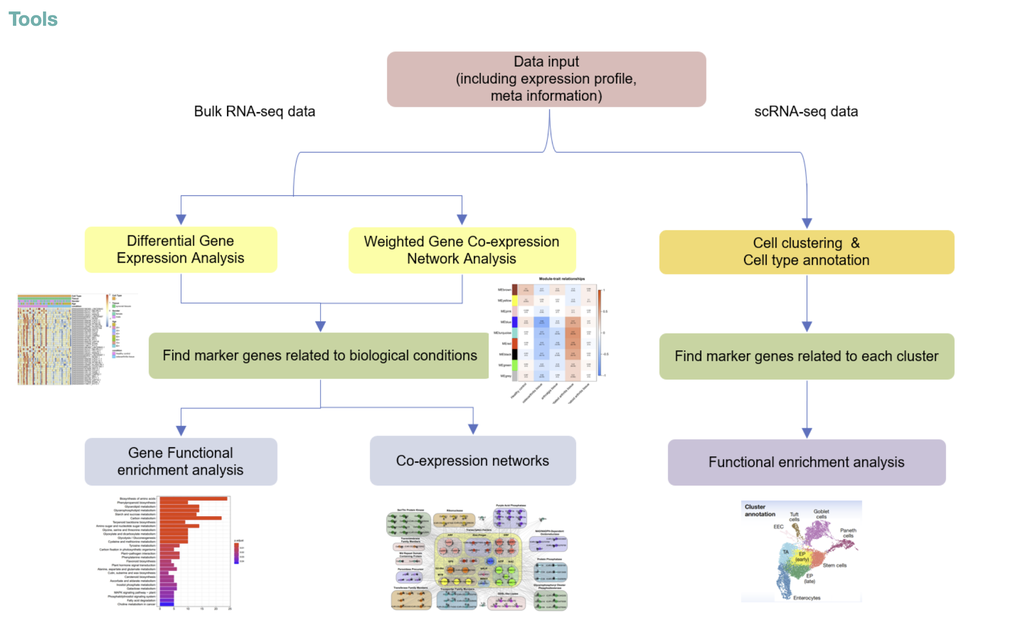

Bulk vs. single-cell — different tools

## Dropout — alternative schematic

*Live deck uses:* the simulated “Sparsity, in numbers” R panel.

[figure not shown]

Each cell yields only ~10–30% of its transcripts (open circles = dropout); a cell type’s transcriptome is recovered by pooling many cells — recreated in our style.

**Note**

**Alternative to the sparsity panel.** Original figure: **Yu *et al.* 2020** (review; on Hope Healey’s Lecture 1, slides ~28–36).

## 3′ UTR annotation — alternative schematic

*Live deck uses:* the text slide “A polyA-capture catch: 3′ UTR annotation” (no figure).

[figure not shown]

3′ capture piles reads at the 3′ end; a well-annotated 3′ UTR captures them, but a missing/truncated UTR sends reads to “intergenic” and the gene is under-counted — recreated in our style.

**Note**

**Visual for the 3′ UTR caveat.** Original concept figure: **Healey *et al.* 2022** (on Hope Healey’s Lecture 1, slides ~25–26).

## Chromium library prep — the full cycle (alt)

*Live deck uses:* `images/lec01_use_chromium_library_prep.svg`

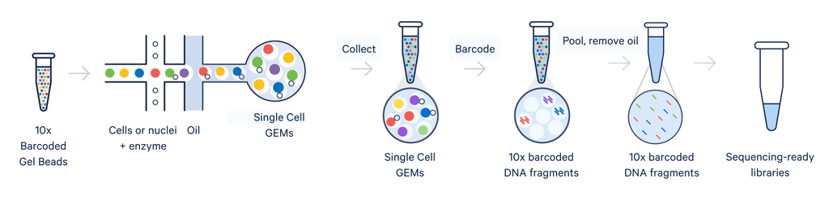

Chromium partitioning + library prep — alternative rendering

## GEM formation — alternative schematic

*Live deck uses:* `images/lec01_use_chromium_library_prep.svg`

[figure not shown]

One cell + one barcoded gel bead + oil partition into a GEM, where lysis, barcoding, and reverse transcription happen — recreated in our style.

**Note**

**Alternative to the library-prep slide.** Original figures: **10x Genomics** Chromium Single Cell documentation — 10xgenomics.com/support/single-cell-gene-expression (on Hope Healey’s Lecture 1, slides ~17–22).

## 10x read structure — alternative schematic

*Live deck uses:* `images/lec01_droplet_barcoding.svg`

[figure not shown]

A 10x 3′ read pair: Read 1 carries the cell barcode + UMI; Read 2 carries the cDNA insert (3′ end) between TSO and polyA — recreated in our style.

**Note**

**Alternative to the barcodes + UMIs slide.** Original figure: **10x Genomics** 3′ reagent kit documentation — 10xgenomics.com/support/single-cell-gene-expression (on Hope Healey’s Lecture 1, slide ~23).

## UMIs in detail — amplification, sequencing, dedup (alt)

*Live deck uses:* `images/lec01_use_umi_deduplication.svg`

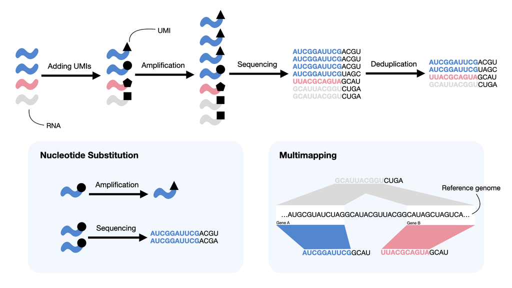

UMI deduplication — alternative rendering

## Raw data processing — BCL → count matrix (alt)

*Live deck uses:* `images/lec01_use_raw_data_processing.svg`

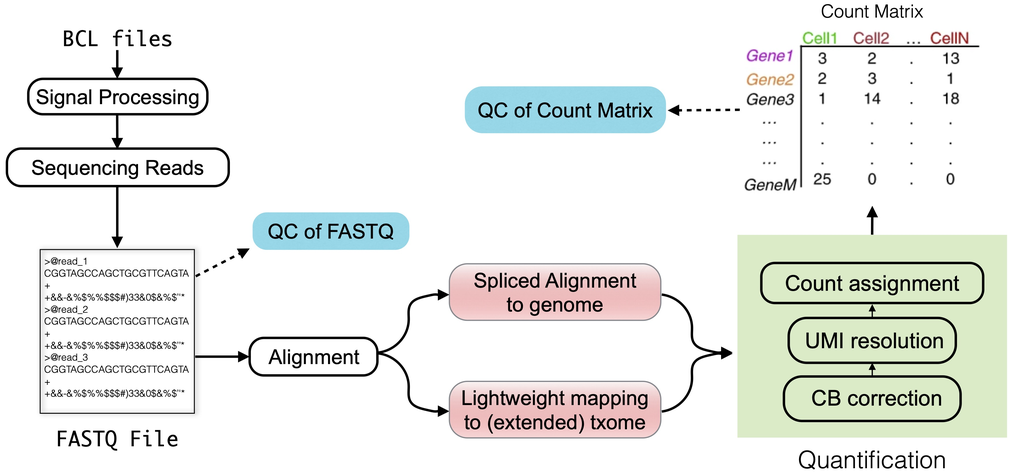

Raw-data processing — alternative rendering

## Pipelines side-by-side (alt)

*Live deck uses:* `images/lec01_data_processing_pipelines.svg`

[figure not shown]

Data processing pipelines — alternative rendering

## Cell Ranger pipeline — alternative schematic

*Live deck uses:* the text slide “Under the hood: what Cell Ranger actually does” (no figure).

[figure not shown]

The fixed `cellranger count` sequence: trim → STAR align → transcriptome/MAPQ → barcode correction → UMI correction → count assignment → unfiltered matrix → OrdMag + EmptyDrops cell calling → filtered matrix — recreated in our style.

**Note**

**Visual for the “under the hood” slide.** Original figures: **10x Genomics** Cell Ranger algorithms overview — 10xgenomics.com/support/software/cell-ranger/latest/algorithms-overview (on Hope Healey’s Lecture 1, slides ~54–69).